# R Notebook

```r
read.csv("Minimum Stipend Data Collection_v1_2.csv")->sos

# colnames(sos)

#us https://www.nature.com/articles/d41586-022-01392-w
read.csv("Biology Benchmark Comparison - 07-23-2024.csv")->us.data
#exchange rate
us.to.cad<-1.38
#convert from usd to cad internally below


#uk https://www.ukri.org/apply-for-funding/studentships-and-doctoral-training/london-weighting-enhanced-stipends-and-co-funding/
#https://trustforlondon.org.uk/data/poverty-thresholds/
  #uk cost of living
#https://homelet.co.uk/homelet-rental-index
  #uk average rent
uk.stipend<-19237
#uk.tuition.stipend<-4786
166*52->uk.cost.of.living.min
304*52->uk.cost.of.living.max
uk.to.cad<-1.78

#convert from gbp to cad
uk.stipend*uk.to.cad->uk.stipend
uk.cost.of.living.max*uk.to.cad->uk.cost.of.living.max
uk.cost.of.living.min*uk.to.cad->uk.cost.of.living.min

#NSERC Scholarships
NSERC.msc<-27000
NSERC.phd<-40000
```

### NOTES from during converstion to a machine readable datafile

McMaster, both departments, provide “more to offset higher tuition” to the international MSc students, but the amount is unspecified.

# Summary information

There were 140 programs within the final dataset, from 38 Universities. There are 71 MSc and 69 PhD programs. Of all of these different degree programs, 50.7142857% were classified as closest to Ecology, while 49.2857143% are in Physics.

Mean domestic tuition was 5824.5582857CAD, median 6240.165CAD. Mean international tuition was 1.5312914^{4}CAD, median 1.497777^{4}CAD. Mean domestic fees were 1681.3175758CAD, international mean 2279.1507576CAD. Total tuition and fees domestic mean is 7376.2457143CAD, while international total was 1.7434514^{4}CAD.

Of the 140 programs within the final dataset, 95 programs have a minimum, while 24 had no information provided that we could access and did not respond to our requests. The average domestic minimum stipend provided was 2.3878032^{4}CAD, median 2.415^{4}CAD. *When support is different than domestic support*, international minimum gross stipend mean is 3.0219923^{4}CAD. Net domestic mean is 1.6407019^{4}CAD while median 1.729052^{4}CAD.

Mean tuition Get score: NA Mean tuition Parse score: NA Mean Stipend Get score: NA Mean Stipend Complete score: NA

Students repay 33.1015381% back to the university in the form of tuition and fees.

Mean MBM Shortfall Domestic: -9681.91 Mean MBM Shortfall International: -1.6779703^{4}

difference between US and Canada: NA

#Plots for the paper.

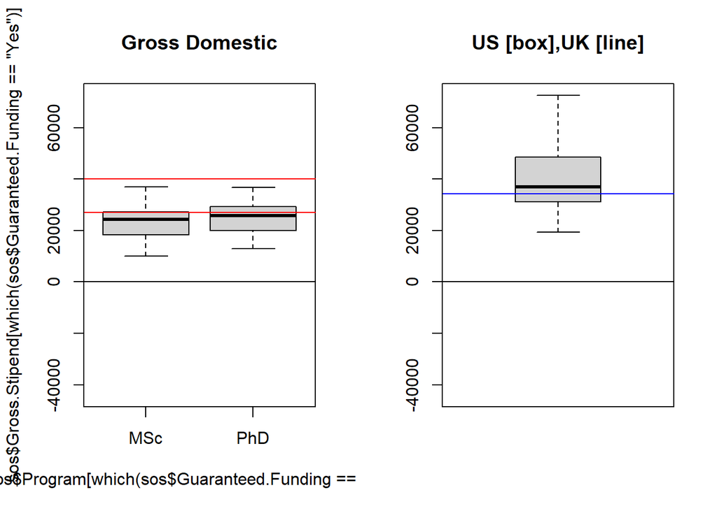

```r
# PhD vs. MSc
  par(mfcol=c(1,2))
      #setting up a stable y to maintain through various plots
        ylimits<-c(min(c(sos$Net.domestic...MBM.Threshold..2024.,
                         {us.data$Annual.guaranteed.salary-us.data$MIT.Living.Wage..1.adult..0.children.}*us.to.cad,
                         uk.stipend-uk.cost.of.living.min,
                         uk.stipend-uk.cost.of.living.max),
              na.rm=T),
                   max(c(sos$Gross.Stipend,
                         {us.data$Annual.guaranteed.salary}*us.to.cad,
                         uk.stipend,
                         uk.stipend),
              na.rm=T)
                   )

  ## Gross Stipend (Domestic) Boxplots
    boxplot(sos$Gross.Stipend[which(sos$Guaranteed.Funding == "Yes")] ~ sos$Program[which(sos$Guaranteed.Funding == "Yes")],
            ylim=ylimits,
            main="Gross Domestic")
    abline(h=0,col="black")
    abline(h=c(NSERC.msc,NSERC.phd),col="red")

    boxplot(us.data$Annual.guaranteed.salary*us.to.cad,
            ylim=ylimits,
            main="US [box],UK [line]")
    abline(h=uk.stipend,col="blue")
    abline(h=0,col="black")
```

Left panel is Canadian domestic students gross minimum stipends, two red are for federally supported students, higher is PhD, lower MSc. Right is for international comparisons. Blue is UK, which provides a single stipend amount (exception: London) for the entire funding system.

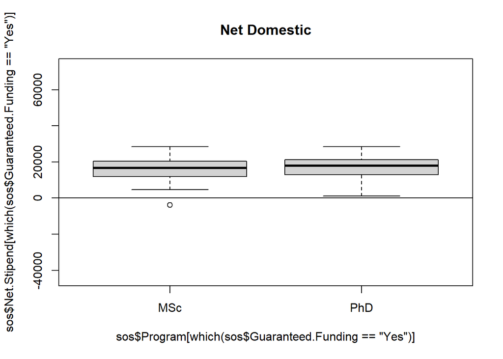

```r
  ## Net Stipend (Domestic) Boxplots
    boxplot(sos$Net.Stipend[which(sos$Guaranteed.Funding == "Yes")] ~ sos$Program[which(sos$Guaranteed.Funding == "Yes")],
            ylim=ylimits,
            main="Net Domestic")
    abline(h=0,col="black")
```

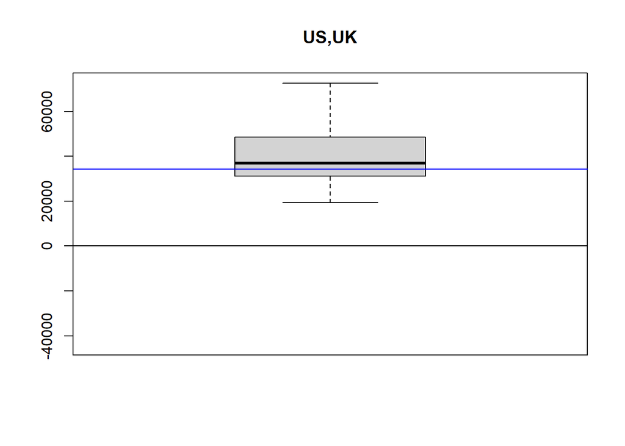

```r
    boxplot(us.data$Annual.guaranteed.salary*us.to.cad,
            ylim=ylimits,
            main="US,UK")
    abline(h=0,col="black")
    abline(h=uk.stipend,col="blue")
```

Same labeling conventions as above.

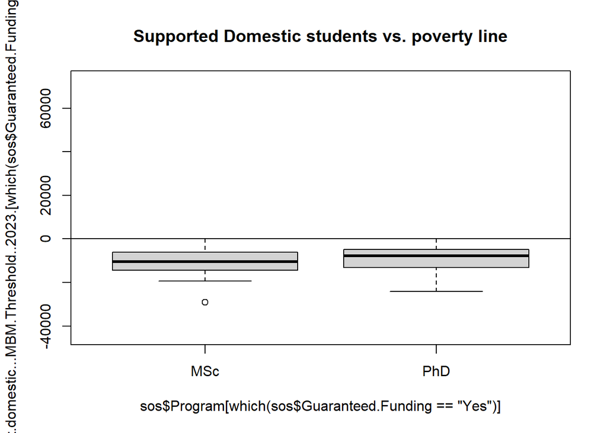

```r
  ## Vs. poverty threshold (Domestic)
  par(mfcol=c(1,1))

    boxplot(sos$Net.domestic...MBM.Threshold..2023.[which(sos$Guaranteed.Funding == "Yes")] ~ sos$Program[which(sos$Guaranteed.Funding == "Yes")],
            ylim=ylimits,
            main="Supported Domestic students vs. poverty line")
        abline(h=0)
```

Same labeling conventions as above. This has had the Market Basket Metric removed, as a measure of poverty provided by the government. Again, this is only for students with support. All students in departments without a minimum graduate stipend have been removed. ## Supplemental figures

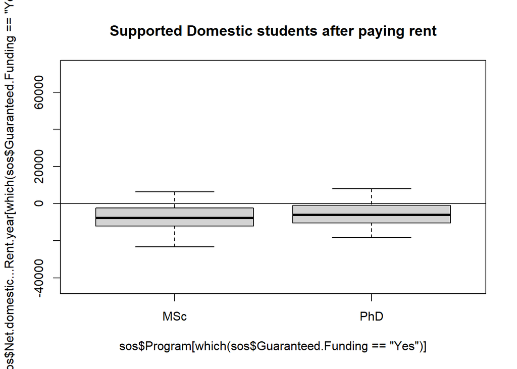

```r
  ## Vs. poverty threshold (Domestic)
  par(mfcol=c(1,1))

    boxplot(sos$Net.domestic...Rent.year[which(sos$Guaranteed.Funding == "Yes")] ~ sos$Program[which(sos$Guaranteed.Funding == "Yes")],
            ylim=ylimits,
            main="Supported Domestic students after paying rent")
        abline(h=0)
```

This is just after paying an average rent for their area and tuition and fees. No food, for example, is included.

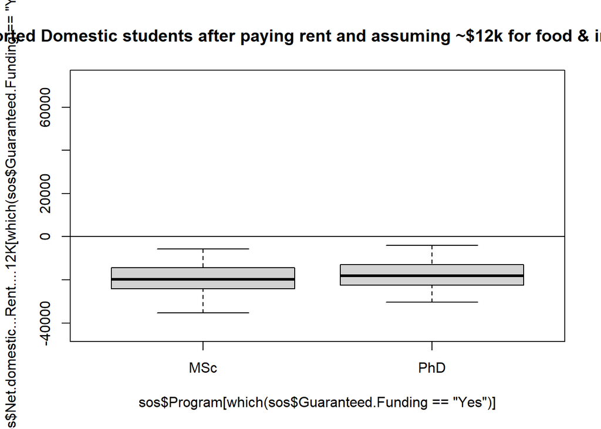

```r
  ## Vs. poverty threshold (Domestic)
  par(mfcol=c(1,1))

    boxplot(sos$Net.domestic...Rent....12K[which(sos$Guaranteed.Funding == "Yes")] ~ sos$Program[which(sos$Guaranteed.Funding == "Yes")],
            ylim=ylimits,
            main="Supported Domestic students after paying rent and assuming ~$12k for food & incidentals")
        abline(h=0)
```

```r
plot(sos$University.Endowment..Millions.of.Dollars.[which(sos$Example.Department == "Physics")],
     sos$Net.Stipend[which(sos$Example.Department == "Physics")],
     pch=16,
     col="purple",
     ylim=c(0,max(sos$Net.Stipend,na.rm=T)),
     main="Univ. Endowment vs. Net Stipends")
points(sos$University.Endowment..Millions.of.Dollars.[which(sos$Example.Department == "Biological Sciences - Ecology")],
     sos$Net.Stipend[which(sos$Example.Department == "Biological Sciences - Ecology")],
     pch=15,
     col="forestgreen")
cor.test(sos$University.Endowment..Millions.of.Dollars.,
     sos$Net.Stipend,use="complete.obs")
```

```
##
##  Pearson's product-moment correlation
##
## data:  sos$University.Endowment..Millions.of.Dollars. and sos$Net.Stipend
## t = 6.991, df = 92, p-value = 4.251e-10
## alternative hypothesis: true correlation is not equal to 0
## 95 percent confidence interval:
##  0.4387558 0.7072245
## sample estimates:
##       cor
## 0.5890101
```

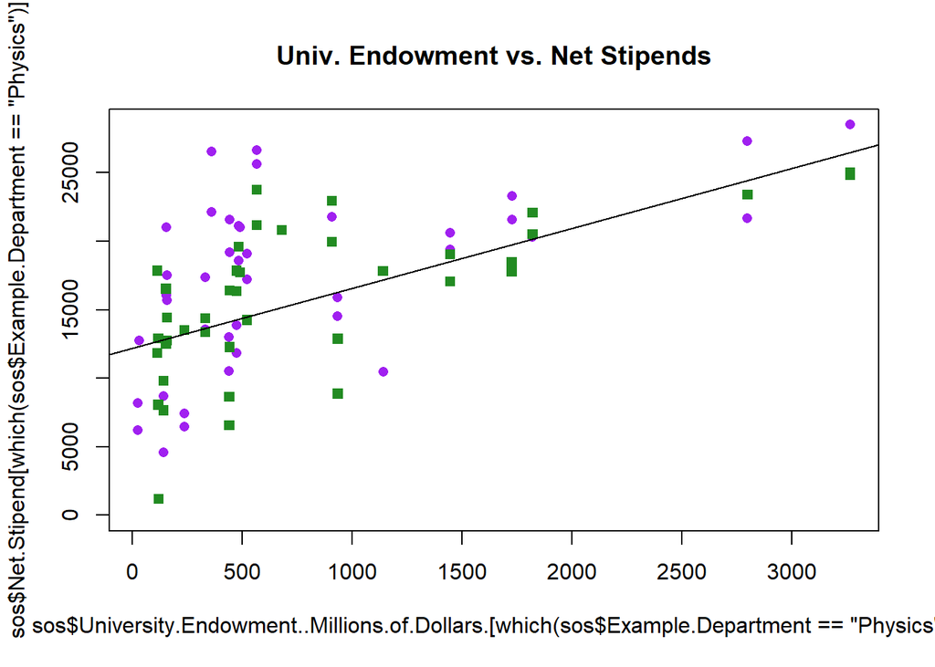

```r
# Line of correlation
  lm(sos$Net.Stipend[which(sos$Example.Department == "Biological Sciences - Ecology")] ~ sos$University.Endowment..Millions.of.Dollars.[which(sos$Example.Department == "Biological Sciences - Ecology")] )->lm.end
  abline(lm.end)
```

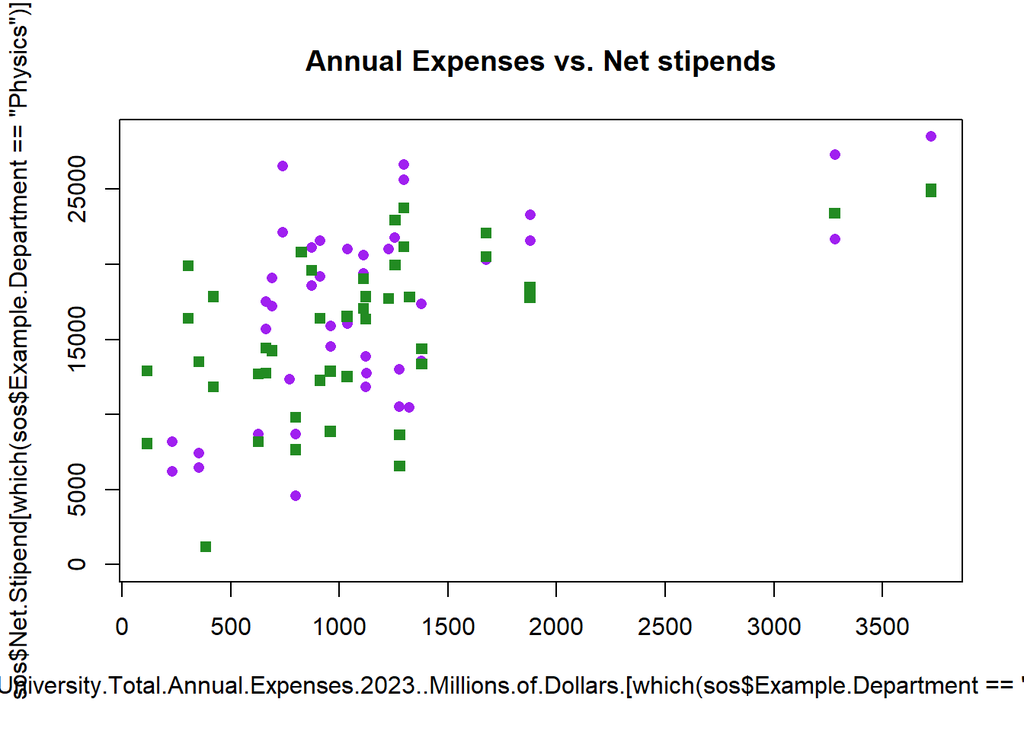

```r
plot(sos$University.Total.Annual.Expenses.2023..Millions.of.Dollars.[which(sos$Example.Department == "Physics")],
     sos$Net.Stipend[which(sos$Example.Department == "Physics")],
     pch=16,
     col="purple",
     ylim=c(0,max(sos$Net.Stipend,na.rm=T)),
     main="Annual Expenses vs. Net stipends")
points(sos$University.Total.Annual.Expenses.2023..Millions.of.Dollars.[which(sos$Example.Department == "Biological Sciences - Ecology")],
     sos$Net.Stipend[which(sos$Example.Department == "Biological Sciences - Ecology")],
     pch=15,
     col="forestgreen")
```

```r
cor.test(sos$University.Total.Annual.Expenses.2023..Millions.of.Dollars.,
     sos$Net.Stipend,use="complete.obs")
```

```
##
##  Pearson's product-moment correlation
##
## data:  sos$University.Total.Annual.Expenses.2023..Millions.of.Dollars. and sos$Net.Stipend
## t = 7.0114, df = 100, p-value = 2.825e-10
## alternative hypothesis: true correlation is not equal to 0
## 95 percent confidence interval:
##  0.4273225 0.6913744
## sample estimates:
##       cor
## 0.5740886
```

Biplots comparing the Universities endowment size vs. the funding received by the student in the first plot, while the second plot compares the annual expenses of the university against the net stipend. We are using the annual expenses as a rough proxy for the size of the university.

# Field comparisons

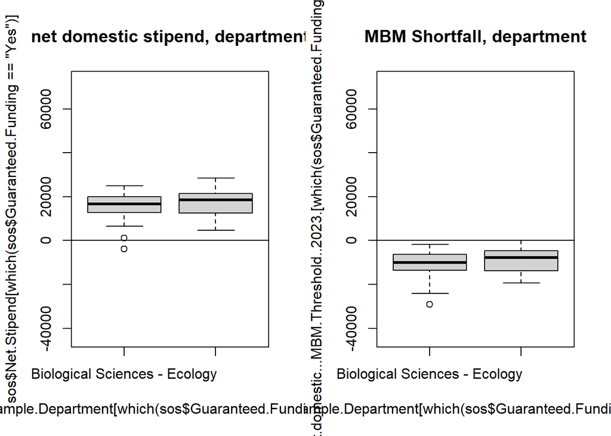

```r
## Vs. field (Domestic)
  par(mfcol=c(1,2))

    boxplot(sos$Net.Stipend[which(sos$Guaranteed.Funding == "Yes")] ~ sos$Example.Department[which(sos$Guaranteed.Funding == "Yes")],
            ylim=ylimits,
            main="net domestic stipend, department")
        abline(h=0)

    boxplot(sos$Net.domestic...MBM.Threshold..2023.[which(sos$Guaranteed.Funding == "Yes")] ~ sos$Example.Department[which(sos$Guaranteed.Funding == "Yes")],
            ylim=ylimits,
            main="MBM Shortfall, department")
        abline(h=0)
```

Comparisons between Biology and Physics, in the same style as the above. Here just net domestic stipend and the MBM Shortfall.

# Provincial Comparisons

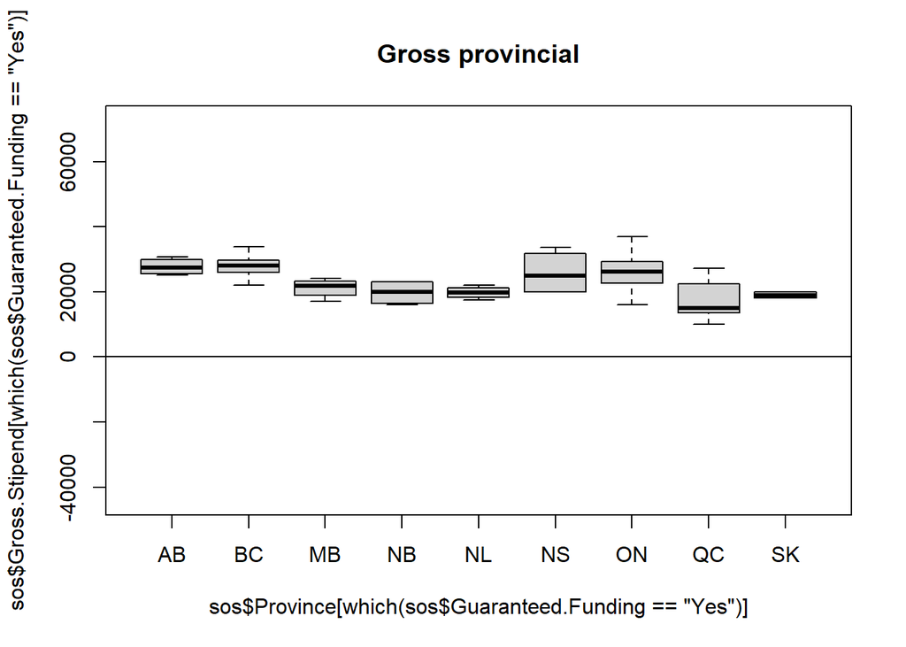

```r
#Province
  ## Gross Stipend (Domestic) Boxplots
    boxplot(sos$Gross.Stipend[which(sos$Guaranteed.Funding == "Yes")] ~ sos$Province[which(sos$Guaranteed.Funding == "Yes")],
        ylim=ylimits,
        main="Gross provincial")
    abline(h=0)
```

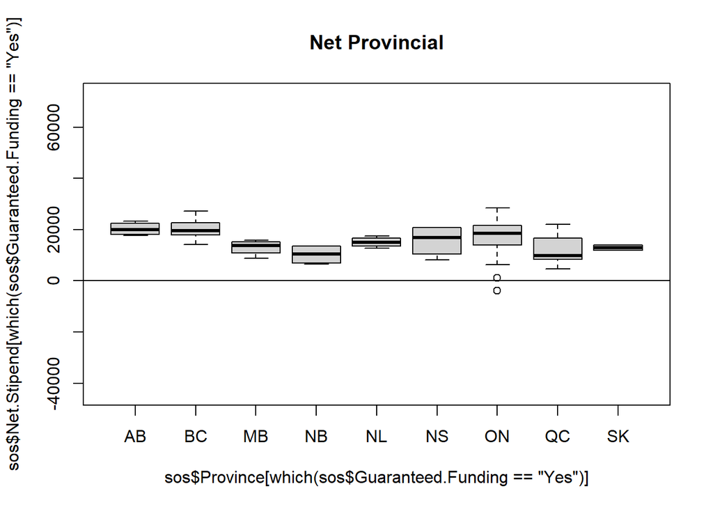

```r
  ## Net Stipend (Domestic) Boxplots
    boxplot(sos$Net.Stipend[which(sos$Guaranteed.Funding == "Yes")] ~ sos$Province[which(sos$Guaranteed.Funding == "Yes")],
            ylim=ylimits,
            main="Net Provincial")
    abline(h=0)
```

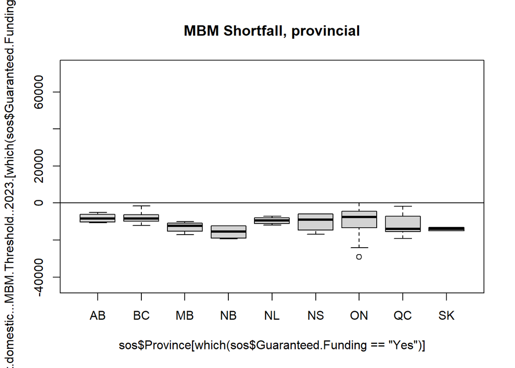

```r
  ## Vs. poverty threshold (Domestic)
    boxplot(sos$Net.domestic...MBM.Threshold..2023.[which(sos$Guaranteed.Funding == "Yes")] ~ sos$Province[which(sos$Guaranteed.Funding == "Yes")],
            ylim=ylimits,
            main="MBM Shortfall, provincial")
    abline(h=0)
```

#### ADD

```r
mean(sos$Total.Int.Fees[which(sos$Guaranteed.Funding == "Yes")]/sos$Gross.Stipend.International[which(sos$Guaranteed.Funding == "Yes")]*100,
       na.rm=T)
```

```
## [1] 50.54291
```

```r
median(sos$Total.Int.Fees[which(sos$Guaranteed.Funding == "Yes")]/sos$Gross.Stipend.International[which(sos$Guaranteed.Funding == "Yes")]*100,
       na.rm=T)
```

```
## [1] 42.88082
```

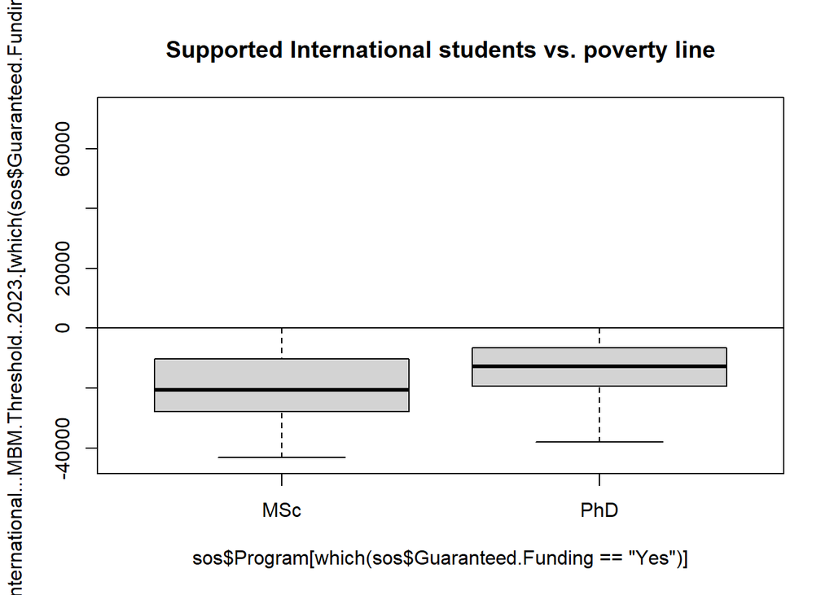

```r
  par(mfcol=c(1,1))

    boxplot(sos$Net.International...MBM.Threshold..2023.[which(sos$Guaranteed.Funding == "Yes")] ~ sos$Program[which(sos$Guaranteed.Funding == "Yes")],
            ylim=ylimits,
            main="Supported International students vs. poverty line")
        abline(h=0)
```

# All plots - NOT PROOFED YET

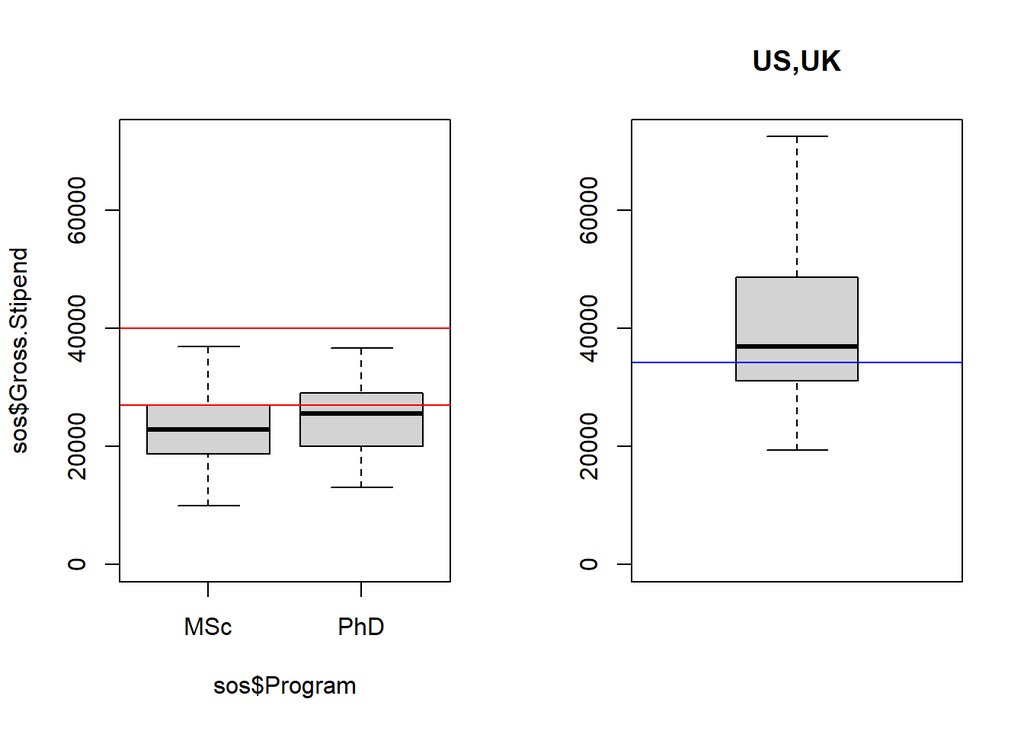

```r
# PhD vs. MSc
  ## Gross Stipend (Domestic) Boxplots
par(mfcol=c(1,2))
    boxplot(sos$Gross.Stipend ~ sos$Program,
            ylim=c(0,max(
              c(sos$Gross.Stipend,us.data$Annual.guaranteed.salary*us.to.cad,uk.stipend),
              na.rm=T)))
    abline(h=c(NSERC.msc,NSERC.phd),col="red")
        boxplot(us.data$Annual.guaranteed.salary*us.to.cad,
            ylim=c(0,max(
              c(sos$Gross.Stipend,us.data$Annual.guaranteed.salary*us.to.cad,uk.stipend),
              na.rm=T)),
            main="US,UK")
    abline(h=uk.stipend,col="blue")
```

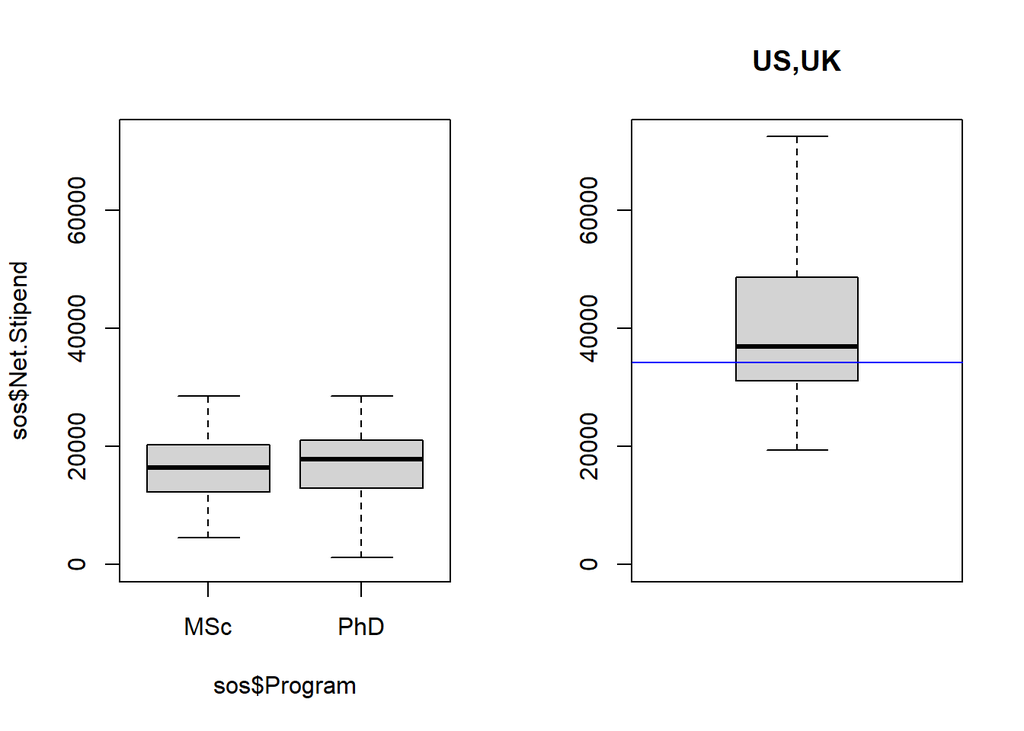

```r
  ## Net Stipend (Domestic) Boxplots
    boxplot(sos$Net.Stipend ~ sos$Program,
            ylim=c(0,max(
              c(sos$Gross.Stipend,us.data$Annual.guaranteed.salary*us.to.cad,uk.stipend),
              na.rm=T)
                   ))
          boxplot(us.data$Annual.guaranteed.salary*us.to.cad,
            ylim=c(0,max(
              c(sos$Gross.Stipend,us.data$Annual.guaranteed.salary*us.to.cad,uk.stipend),
              na.rm=T)),
            main="US,UK")
        abline(h=uk.stipend,col="blue")
```

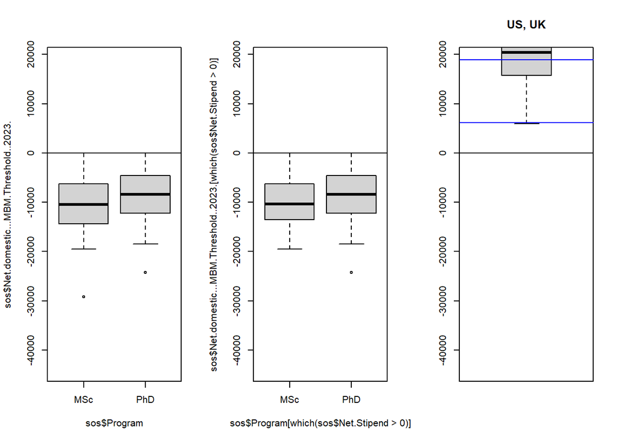

```r
  ## Vs. poverty threshold (Domestic)
  par(mfcol=c(1,3))
        ylimits<-c(min(c(sos$Net.domestic...MBM.Threshold..2023.,
                         {us.data$Annual.guaranteed.salary-us.data$MIT.Living.Wage..1.adult..0.children.}*us.to.cad,
                         uk.stipend-uk.cost.of.living.min,
                         uk.stipend-uk.cost.of.living.max),
              na.rm=T),
                   max(c(sos$Net.domestic...MBM.Threshold..2023.,
                         {us.data$Annual.guaranteed.salary-us.data$MIT.Living.Wage..1.adult..0.children.}*us.to.cad,
                         uk.stipend-uk.cost.of.living.min,
                         uk.stipend-uk.cost.of.living.max),
              na.rm=T)
                   )
    boxplot(sos$Net.domestic...MBM.Threshold..2023. ~ sos$Program,
            ylim=ylimits)
        abline(h=0)
    boxplot(sos$Net.domestic...MBM.Threshold..2023.[which(sos$Net.Stipend > 0)] ~ sos$Program[which(sos$Net.Stipend > 0)],
            ylim=ylimits)
        abline(h=0)

#    boxplot({us.data$Annual.guaranteed.salary-us.data$MIT.Living.Wage..1.adult..0.children.
#            }*us.to.cad,
#            ylim=ylimits,
#            main="US (MIT), UK")
#    abline(h=0)
#    abline(h=c(uk.stipend-uk.cost.of.living.min,
#               uk.stipend-uk.cost.of.living.max),col="blue")



#    boxplot({us.data$Salary-us.data$MIT.Living.by.appt.term
#            }*us.to.cad,
#            ylim=ylimits,
#            main="US (MIT), UK")
#    abline(h=0)
#    abline(h=c(uk.stipend-uk.cost.of.living.min,
#               uk.stipend-uk.cost.of.living.max),col="blue")

        boxplot({us.data$Salary-us.data$Poverty.Line.for.appointment.term
            }*us.to.cad,
            ylim=ylimits,
            main="US, UK")
    abline(h=0)
    abline(h=c(uk.stipend-uk.cost.of.living.min,
               uk.stipend-uk.cost.of.living.max),col="blue")
```

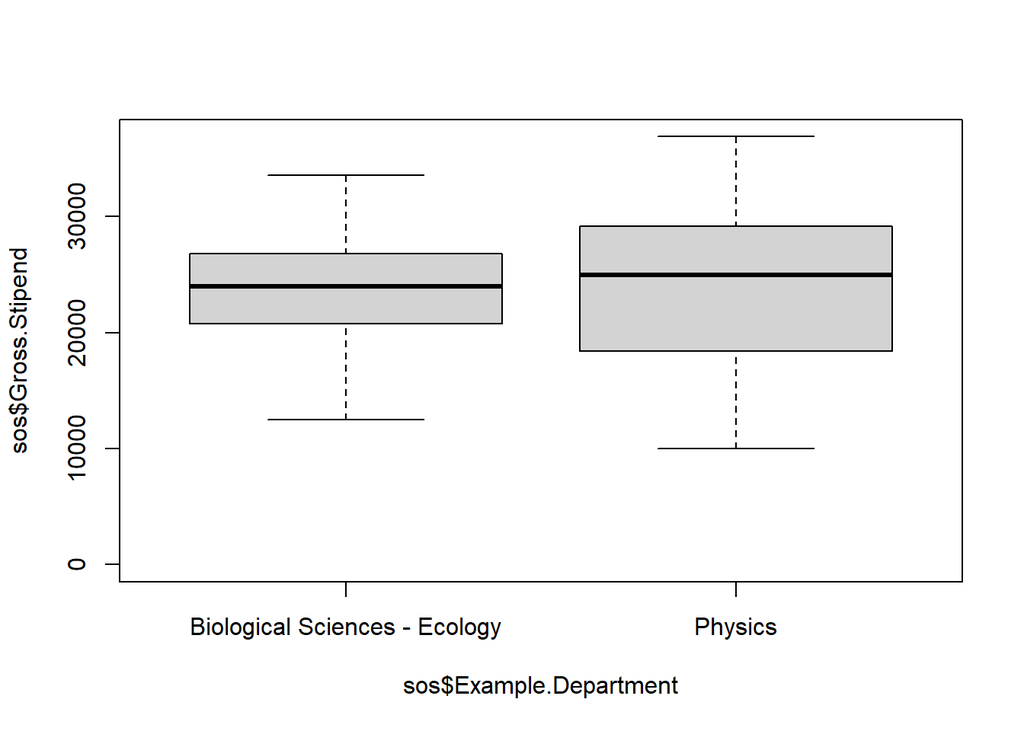

```r
    par(mfcol=c(1,1))

# Bio vs. Physics
  ## Gross Stipend (Domestic) Boxplots
    boxplot(sos$Gross.Stipend ~ sos$Example.Department,
            ylim=c(0,max(sos$Gross.Stipend, na.rm=T)))
```

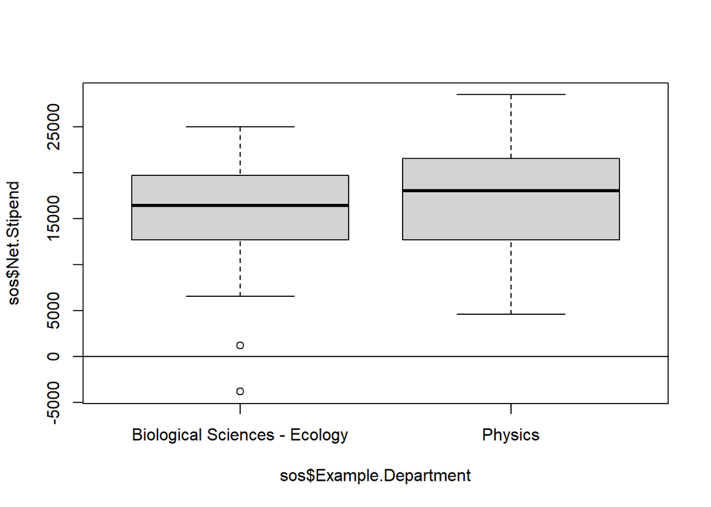

```r
  ## Net Stipend (Domestic) Boxplots
    boxplot(sos$Net.Stipend ~ sos$Example.Department)
    abline(h=0)
```

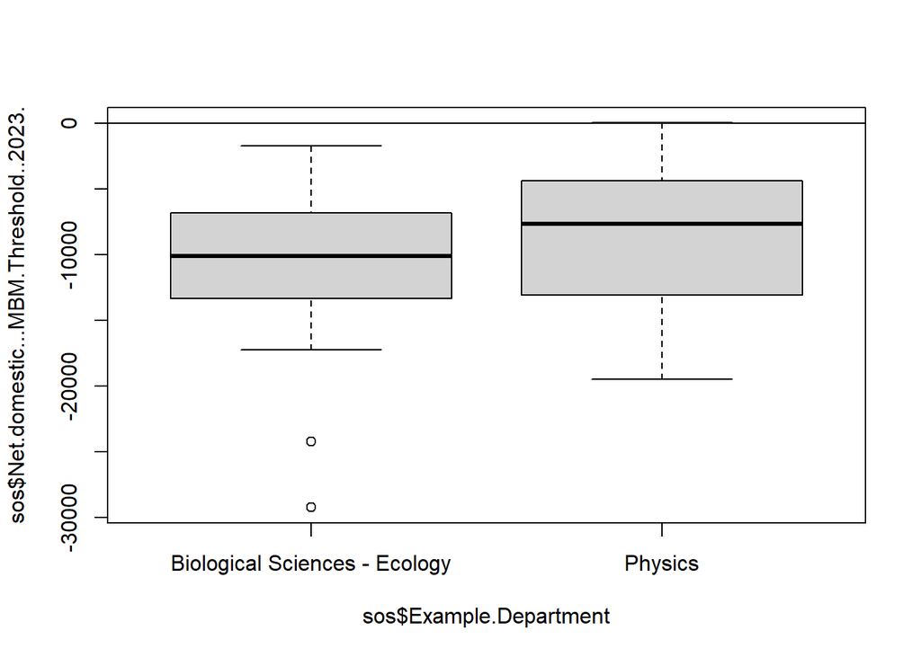

```r
  ## Vs. poverty threshold (Domestic)
    boxplot(sos$Net.domestic...MBM.Threshold..2023. ~ sos$Example.Department)
    abline(h=0)
```

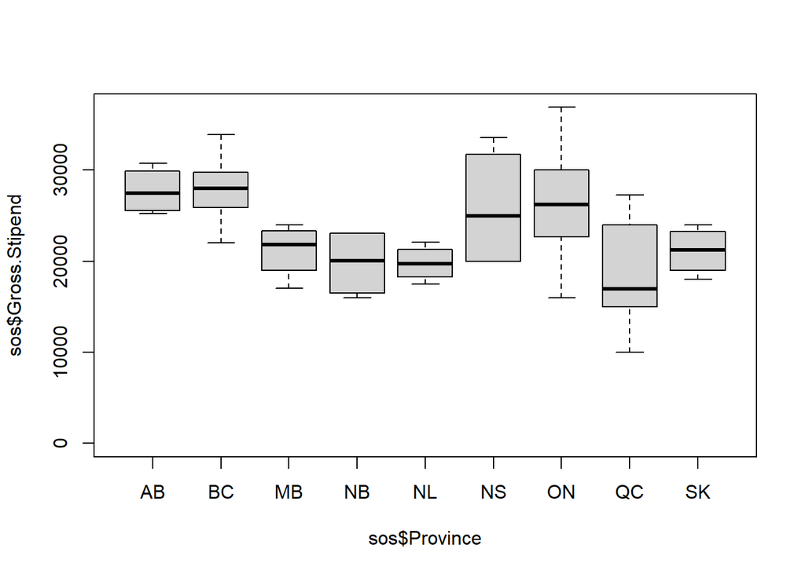

```r
#Province
  ## Gross Stipend (Domestic) Boxplots
    boxplot(sos$Gross.Stipend ~ sos$Province,
        ylim=c(0,max(sos$Gross.Stipend, na.rm=T)))
```

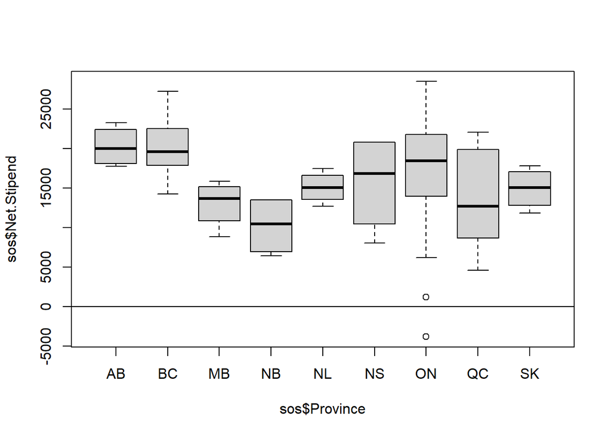

```r
  ## Net Stipend (Domestic) Boxplots
    boxplot(sos$Net.Stipend ~ sos$Province)
    abline(h=0)
```

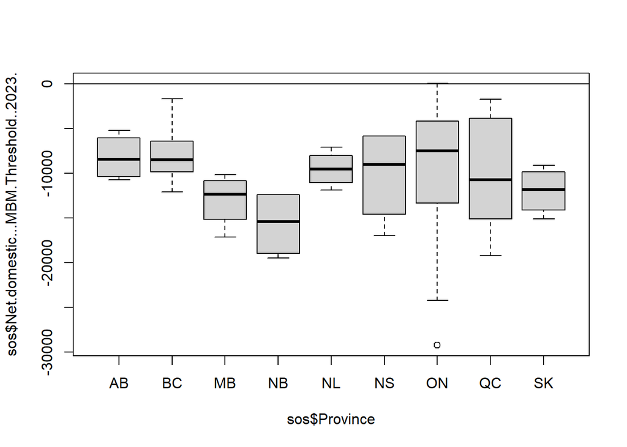

```r
  ## Vs. poverty threshold (Domestic)
    boxplot(sos$Net.domestic...MBM.Threshold..2023. ~ sos$Province)
    abline(h=0)
```

```r
    #What fraction do university's collect as fees/tuition?
mean(sos$Total.Domestic.Fees[which(sos$Net.Stipend > 0)]/sos$Gross.Stipend[which(sos$Net.Stipend > 0)]*100,
     na.rm=T)
```

```
## [1] 31.80864
```

```r
median(sos$Total.Domestic.Fees[which(sos$Net.Stipend > 0)]/sos$Gross.Stipend[which(sos$Net.Stipend > 0)]*100,
     na.rm=T)
```

```
## [1] 30.79695
```

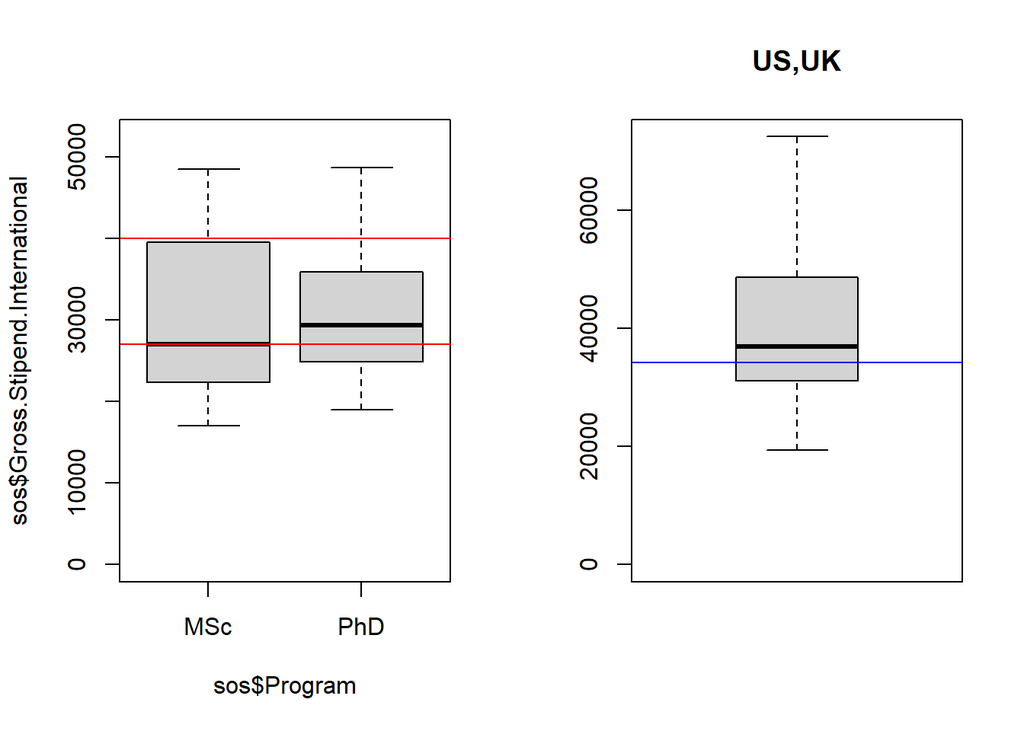

```r
# PhD vs. MSc

#add code here to fix the ylimits

  ## Gross Stipend (Int) Boxplots
par(mfcol=c(1,2))
        boxplot(sos$Gross.Stipend.International ~ sos$Program,
            ylim=c(0,max(
              c(sos$Gross.Stipend.International,us.data$Salary,uk.stipend),
              na.rm=T)))
        abline(h=c(NSERC.msc,NSERC.phd),col="red")

        boxplot(us.data$Annual.guaranteed.salary*us.to.cad,
            ylim=c(0,max(
              c(sos$Gross.Stipend.International,us.data$Annual.guaranteed.salary*us.to.cad,uk.stipend),
              na.rm=T)),
            main="US,UK")
    abline(h=uk.stipend,col="blue")
```

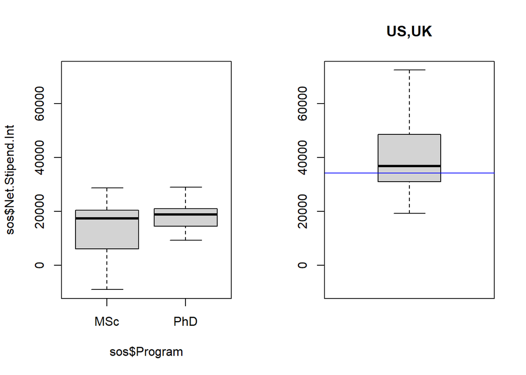

```r
    par(mfcol=c(1,1))

  ## Net Stipend (Int) Boxplots
    par(mfcol=c(1,2))
    boxplot(sos$Net.Stipend.Int ~ sos$Program,
             ylim=c(
               min(
                c(sos$Net.Stipend.Int,us.data$Annual.guaranteed.salary*us.to.cad,uk.stipend
                  ),
               na.rm=T)
              ,max(
                c(sos$Net.Stipend.Int,us.data$Annual.guaranteed.salary*us.to.cad,uk.stipend),
                na.rm=T)
                   )
    )
        boxplot(us.data$Annual.guaranteed.salary*us.to.cad,
            ylim=c(
               min(
                c(sos$Net.Stipend.Int,us.data$Annual.guaranteed.salary*us.to.cad,uk.stipend
                  ),
               na.rm=T)
              ,max(
                c(sos$Net.Stipend.Int,us.data$Annual.guaranteed.salary*us.to.cad,uk.stipend),
                na.rm=T)
                   ),
            main="US,UK")
    abline(h=uk.stipend,col="blue")
```

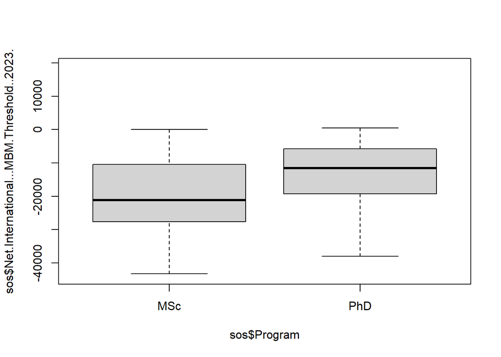

```r
        par(mfcol=c(1,1))

  ## Vs. poverty threshold (int)
    boxplot(sos$Net.International...MBM.Threshold..2023. ~ sos$Program,
            ylim=ylimits)
```

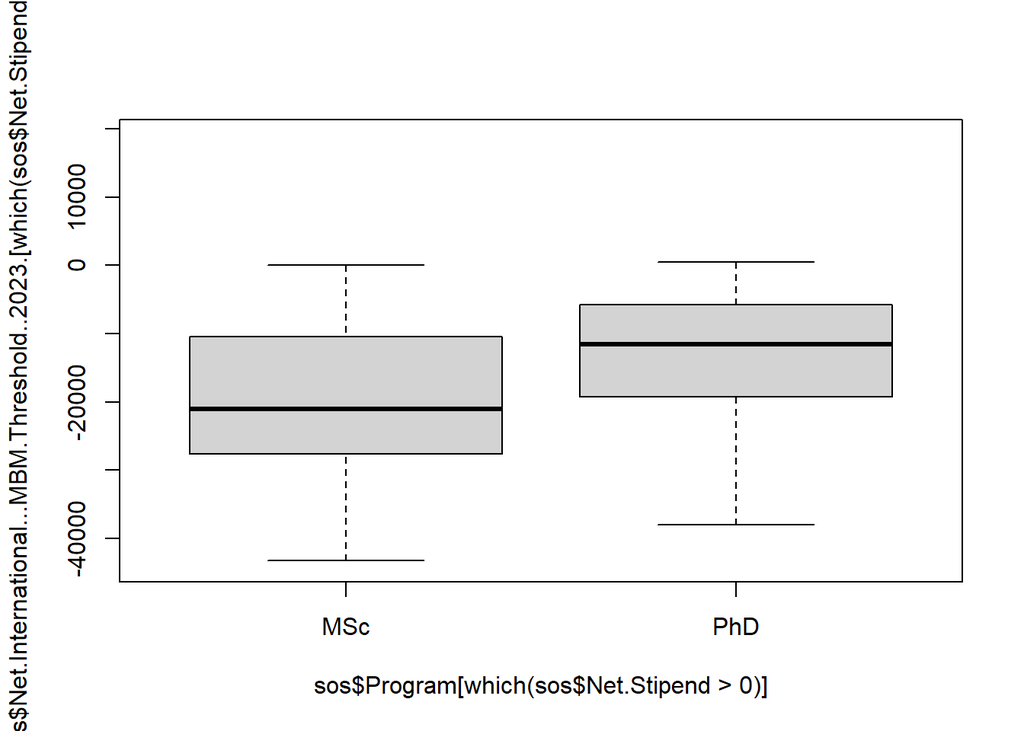

```r
       boxplot(sos$Net.International...MBM.Threshold..2023.[which(sos$Net.Stipend > 0)] ~ sos$Program[which(sos$Net.Stipend > 0)],
            ylim=ylimits)
```

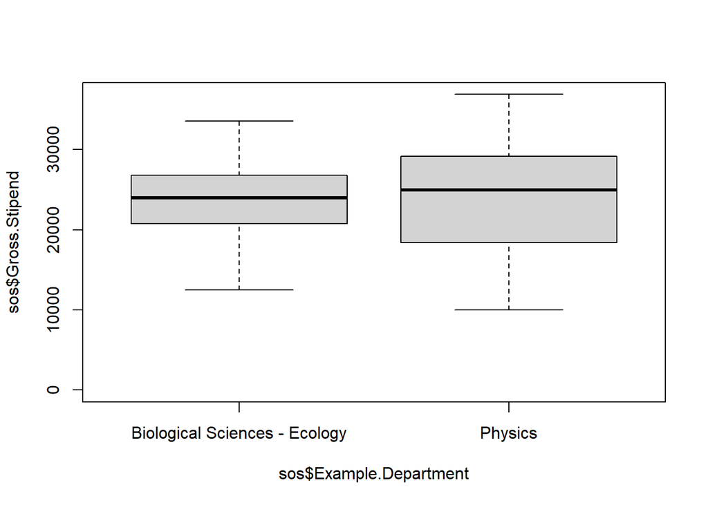

```r
# Bio vs. Physics
  ## Gross Stipend (Domestic) Boxplots
    boxplot(sos$Gross.Stipend ~ sos$Example.Department,
            ylim=c(0,max(sos$Gross.Stipend, na.rm=T)))
```

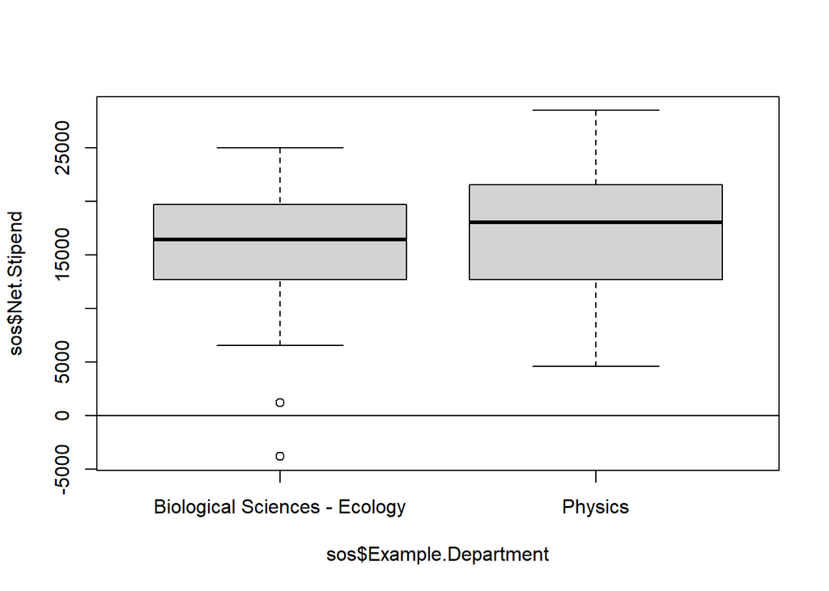

```r
  ## Net Stipend (Domestic) Boxplots
    boxplot(sos$Net.Stipend ~ sos$Example.Department)
    abline(h=0)
```

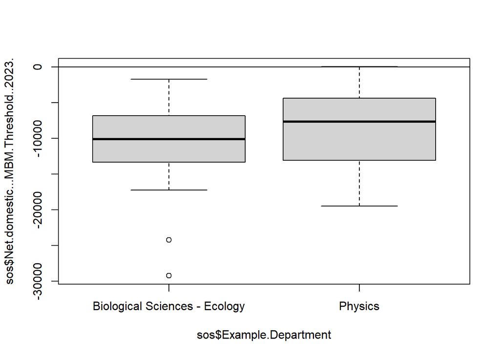

```r
  ## Vs. poverty threshold (Domestic)
    boxplot(sos$Net.domestic...MBM.Threshold..2023. ~ sos$Example.Department)
    abline(h=0)
```

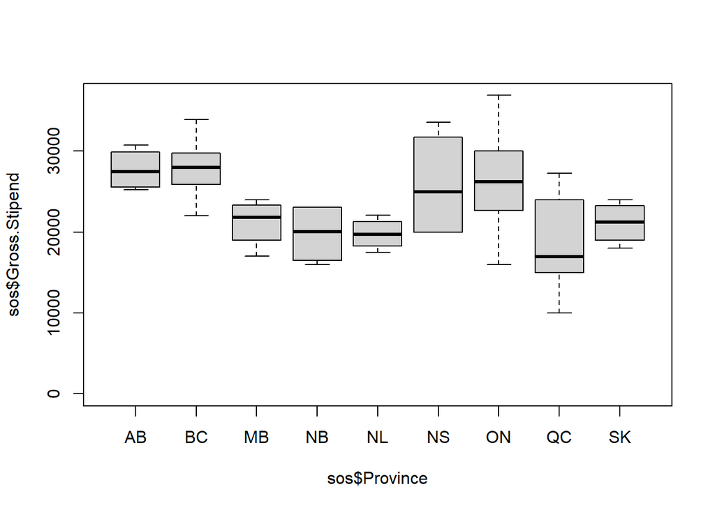

```r
#Province
  ## Gross Stipend (Domestic) Boxplots
    boxplot(sos$Gross.Stipend ~ sos$Province,
        ylim=c(0,max(sos$Gross.Stipend, na.rm=T)))
```

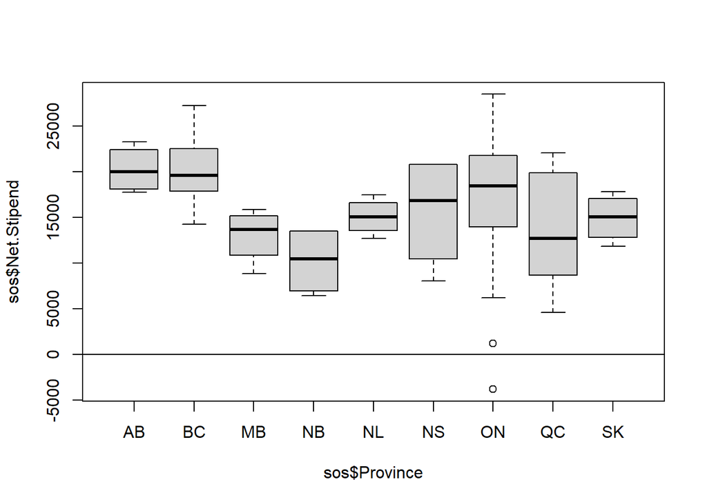

```r
  ## Net Stipend (Domestic) Boxplots
    boxplot(sos$Net.Stipend ~ sos$Province)
    abline(h=0)
```

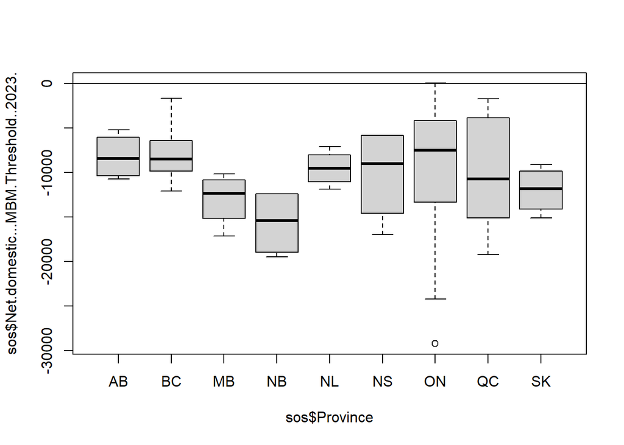

```r
  ## Vs. poverty threshold (Domestic)
    boxplot(sos$Net.domestic...MBM.Threshold..2023. ~ sos$Province)
    abline(h=0)
```

```r
        #What fraction do university's collect as fees/tuition?

    mean(sos$Total.Int.Fees[which(sos$Net.Stipend > 0)]/sos$Gross.Stipend.International[which(sos$Net.Stipend > 0)]*100,
     na.rm=T)
```

```
## [1] 49.11046
```

```r
median(sos$Total.Int.Fees[which(sos$Net.Stipend > 0)]/sos$Gross.Stipend.International[which(sos$Net.Stipend > 0)]*100,
       na.rm=T)
```

```
## [1] 41.29366
```

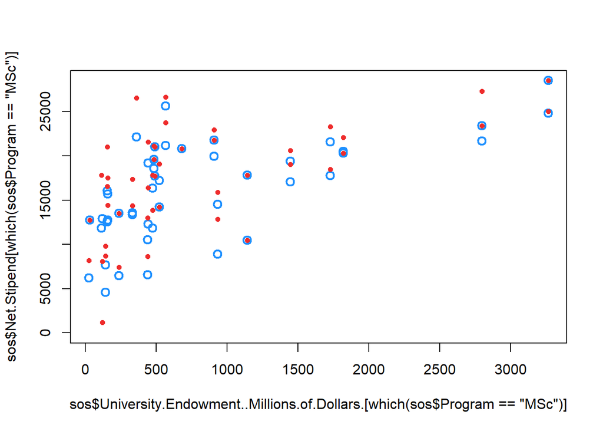

```r
plot(sos$University.Endowment..Millions.of.Dollars.[which(sos$Program == "MSc")],
     sos$Net.Stipend[which(sos$Program == "MSc")],
     pch=1,
     lwd=2,
     cex=1.25,
     col="dodgerblue",
     ylim=c(0,max(sos$Net.Stipend,na.rm=T)))
points(sos$University.Endowment..Millions.of.Dollars.[which(sos$Program == "PhD")],
     sos$Net.Stipend[which(sos$Program == "PhD")],
     pch=16,
     cex=.75,
     col="firebrick2")
```

```r
cor.test(sos$University.Endowment..Millions.of.Dollars.,
     sos$Net.Stipend,use="complete.obs")
```

```
##
##  Pearson's product-moment correlation
##
## data:  sos$University.Endowment..Millions.of.Dollars. and sos$Net.Stipend
## t = 6.991, df = 92, p-value = 4.251e-10
## alternative hypothesis: true correlation is not equal to 0
## 95 percent confidence interval:
##  0.4387558 0.7072245
## sample estimates:
##       cor
## 0.5890101
```

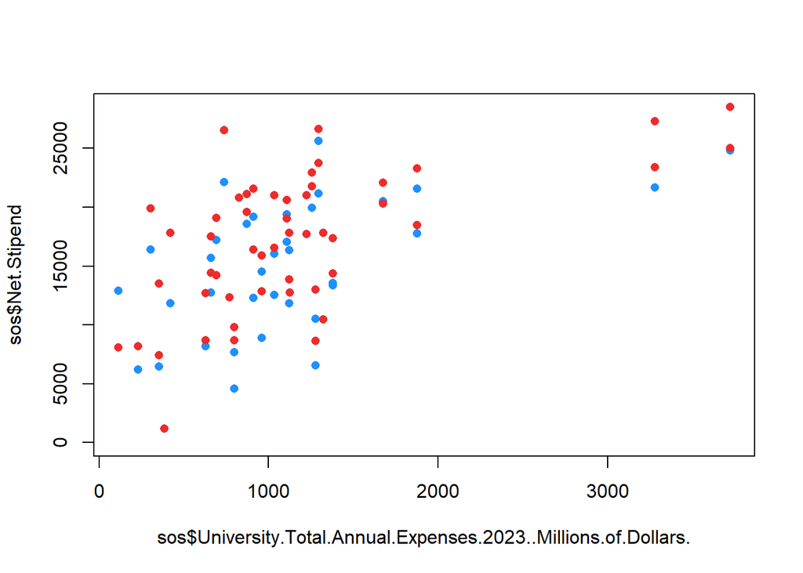

```r
plot(sos$University.Total.Annual.Expenses.2023..Millions.of.Dollars.,
     sos$Net.Stipend,
     pch=16,
     col="dodgerblue",
     ylim=c(0,max(sos$Net.Stipend,na.rm=T)))
points(sos$University.Total.Annual.Expenses.2023..Millions.of.Dollars.[which(sos$Program == "PhD")],
     sos$Net.Stipend[which(sos$Program == "PhD")],
     pch=16,
     col="firebrick2")
```

```r
cor.test(sos$University.Total.Annual.Expenses.2023..Millions.of.Dollars.,
     sos$Net.Stipend,use="complete.obs")
```

```
##
##  Pearson's product-moment correlation
##
## data:  sos$University.Total.Annual.Expenses.2023..Millions.of.Dollars. and sos$Net.Stipend
## t = 7.0114, df = 100, p-value = 2.825e-10
## alternative hypothesis: true correlation is not equal to 0
## 95 percent confidence interval:
##  0.4273225 0.6913744
## sample estimates:
##       cor
## 0.5740886
```

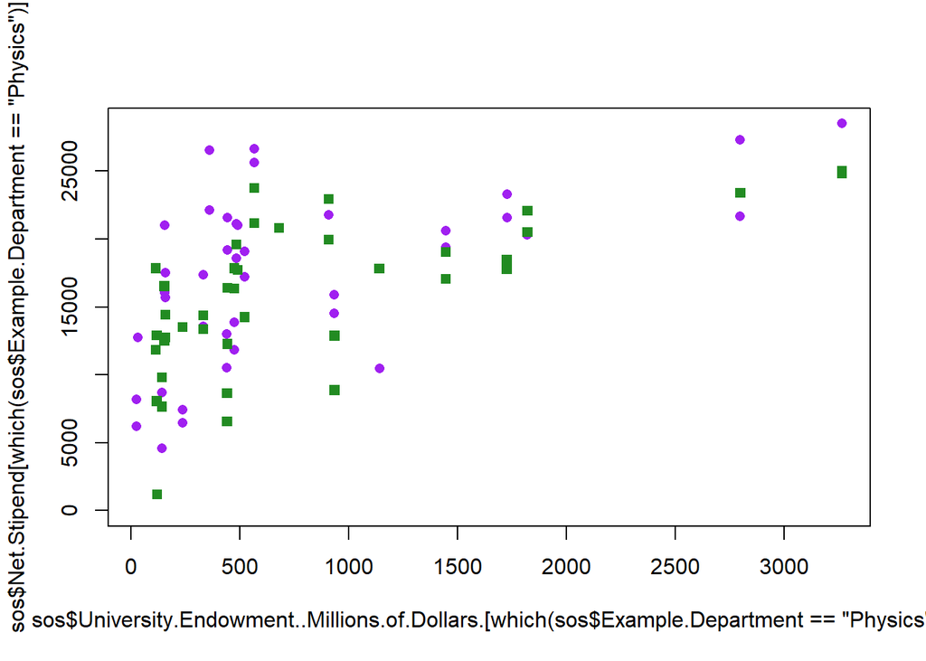

```r
plot(sos$University.Endowment..Millions.of.Dollars.[which(sos$Example.Department == "Physics")],
     sos$Net.Stipend[which(sos$Example.Department == "Physics")],
     pch=16,
     col="purple",
     ylim=c(0,max(sos$Net.Stipend,na.rm=T)))
points(sos$University.Endowment..Millions.of.Dollars.[which(sos$Example.Department == "Biological Sciences - Ecology")],
     sos$Net.Stipend[which(sos$Example.Department == "Biological Sciences - Ecology")],
     pch=15,
     col="forestgreen")
```

```r
cor.test(sos$University.Endowment..Millions.of.Dollars.,
     sos$Net.Stipend,use="complete.obs")
```

```
##
##  Pearson's product-moment correlation
##
## data:  sos$University.Endowment..Millions.of.Dollars. and sos$Net.Stipend
## t = 6.991, df = 92, p-value = 4.251e-10
## alternative hypothesis: true correlation is not equal to 0
## 95 percent confidence interval:
##  0.4387558 0.7072245
## sample estimates:
##       cor
## 0.5890101
```

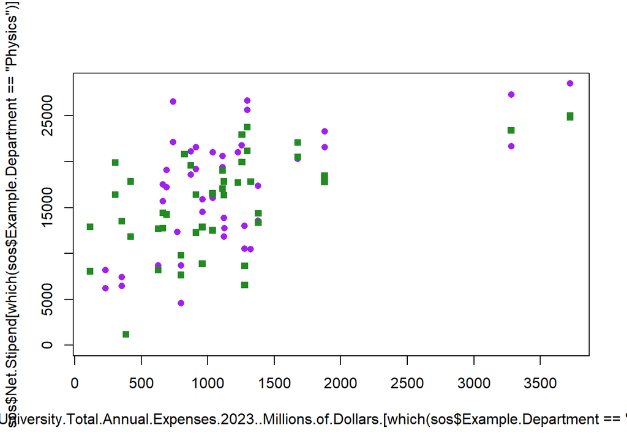

```r
plot(sos$University.Total.Annual.Expenses.2023..Millions.of.Dollars.[which(sos$Example.Department == "Physics")],
     sos$Net.Stipend[which(sos$Example.Department == "Physics")],
     pch=16,
     col="purple",
     ylim=c(0,max(sos$Net.Stipend,na.rm=T)))
points(sos$University.Total.Annual.Expenses.2023..Millions.of.Dollars.[which(sos$Example.Department == "Biological Sciences - Ecology")],
     sos$Net.Stipend[which(sos$Example.Department == "Biological Sciences - Ecology")],
     pch=15,
     col="forestgreen")
```

```r
cor.test(sos$University.Total.Annual.Expenses.2023..Millions.of.Dollars.,
     sos$Net.Stipend,use="complete.obs")
```

```
##
##  Pearson's product-moment correlation
##
## data:  sos$University.Total.Annual.Expenses.2023..Millions.of.Dollars. and sos$Net.Stipend
## t = 7.0114, df = 100, p-value = 2.825e-10
## alternative hypothesis: true correlation is not equal to 0
## 95 percent confidence interval:
##  0.4273225 0.6913744
## sample estimates:
##       cor
## 0.5740886
```

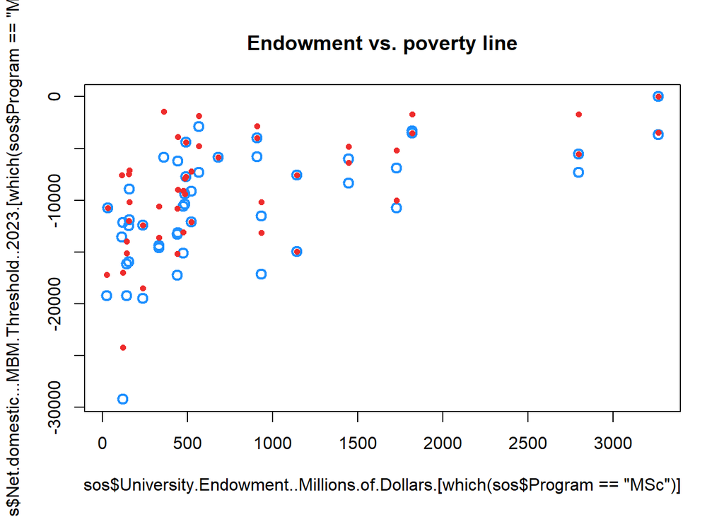

```r
# Vs. post MBM

plot(sos$University.Endowment..Millions.of.Dollars.[which(sos$Program == "MSc")],
     sos$Net.domestic...MBM.Threshold..2023.[which(sos$Program == "MSc")],
     pch=1,
     lwd=2,
     cex=1.25,
     col="dodgerblue",
     ylim=c(min(sos$Net.domestic...MBM.Threshold..2023.,na.rm=T),0),
     main="Endowment vs. poverty line")
points(sos$University.Endowment..Millions.of.Dollars.[which(sos$Program == "PhD")],
     sos$Net.domestic...MBM.Threshold..2023.[which(sos$Program == "PhD")],
     pch=16,
     cex=.75,
     col="firebrick2")
```

```r
#points(sos$Endowment[which(sos$University == "Victoria")],
#     sos$Net.domestic...MBM.Threshold..2024.[which(sos$University == "Victoria")],
#     pch=16,
#     cex=1,
#     col="green")
cor.test(sos$University.Endowment..Millions.of.Dollars.,
     sos$Net.domestic...MBM.Threshold..2023.,use="complete.obs")
```

```
##
##  Pearson's product-moment correlation
##
## data:  sos$University.Endowment..Millions.of.Dollars. and sos$Net.domestic...MBM.Threshold..2023.
## t = 6.3555, df = 92, p-value = 7.856e-09
## alternative hypothesis: true correlation is not equal to 0
## 95 percent confidence interval:
##  0.3938135 0.6789835
## sample estimates:
##       cor
## 0.5523561
```

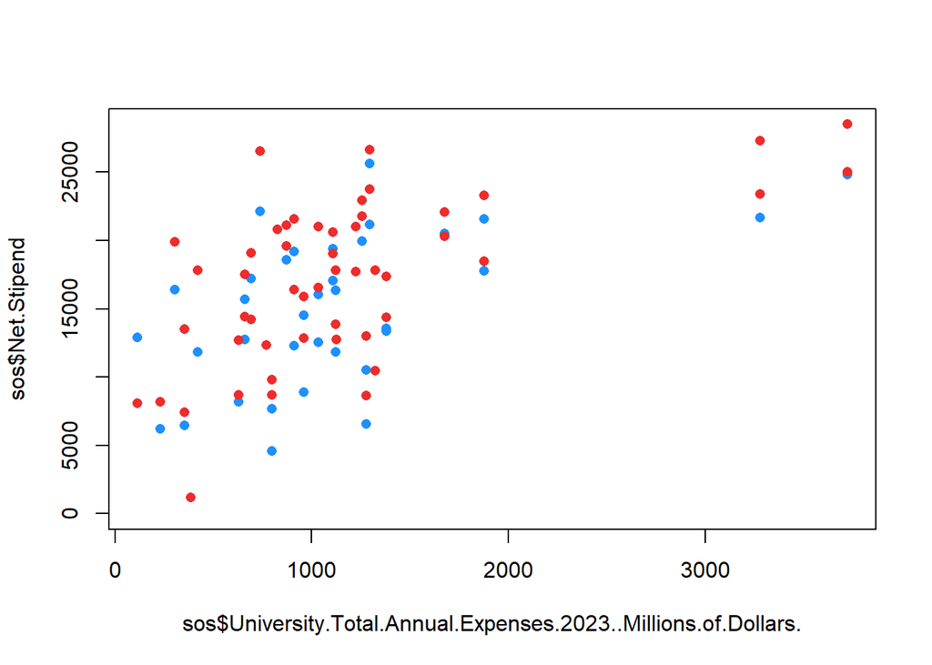

```r
plot(sos$University.Total.Annual.Expenses.2023..Millions.of.Dollars.,
     sos$Net.Stipend,
     pch=16,
     col="dodgerblue",
     ylim=c(0,max(sos$Net.Stipend,na.rm=T)))
points(sos$University.Total.Annual.Expenses.2023..Millions.of.Dollars.[which(sos$Program == "PhD")],
     sos$Net.Stipend[which(sos$Program == "PhD")],
     pch=16,
     col="firebrick2")
```

```r
cor.test(sos$University.Total.Annual.Expenses.2023..Millions.of.Dollars.,
     sos$Net.Stipend,use="complete.obs")
```

```
##
##  Pearson's product-moment correlation
##
## data:  sos$University.Total.Annual.Expenses.2023..Millions.of.Dollars. and sos$Net.Stipend
## t = 7.0114, df = 100, p-value = 2.825e-10
## alternative hypothesis: true correlation is not equal to 0
## 95 percent confidence interval:
##  0.4273225 0.6913744
## sample estimates:
##       cor
## 0.5740886
```